# ST517 Final Re-Do

Zoe Aiello

2023-02-11

# Introduction

**Background**

The data in this report comes from the [2011-2015 American Community Survey 5-year Public Use Microdata Sample](https://www.census.gov/programs-surveys/acs/microdata/documentation.2015.html#list-tab-TNHVWJKXFRL54R02Q0). It contains data on Oregon housing units for 15,166 households. There are 16 variables describing the housing unit which are all reported in the appendix. The purpose of this report to:

1. Investigate whether people living in apartments pay less in electricity than those living in houses and, if so, by how much?
2. Create a predictive model for household electricity costs in Oregon.

**Data Exploration**

Table 1

|  | Total |
| --- | --- |
| Sample Size | 13774 |
| Number of Variables | 15 |

Table 2

|  | Min | First.Quartile | Median | Mean | Third.Quartile | Max |
| --- | --- | --- | --- | --- | --- | --- |
| Electricity Cost (monthly) | 4 | 70 | 100 | 114.08538 | 140 | 540 |
| Electricity Cost (Apartments, monthly) | 4 | 50 | 70 | 81.16719 | 100 | 540 |
| Electricity Cost (Houses, monthly) | 4 | 70 | 100 | 121.60014 | 150 | 540 |

After removing vacant lots, homes with no bedrooms, and the serial number variable, the data set contains 13774 units and 15 variables (Table 1). Electricity costs are higher for houses, on average, than for apartments (Table 2). The median electricity cost for an apartment in Oregon is $70 per month and the median electricity cost for a house in Oregon is $100 per month (Table 2).

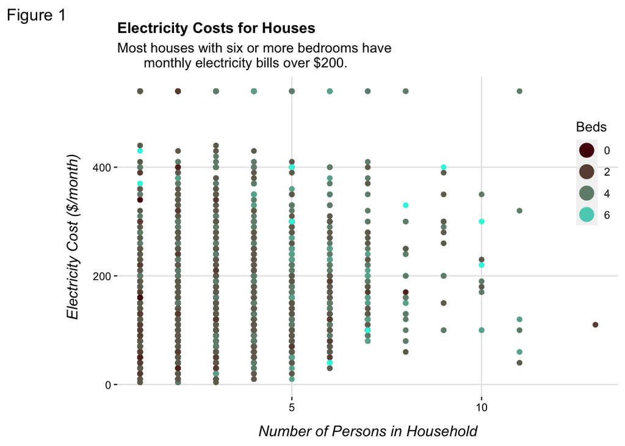

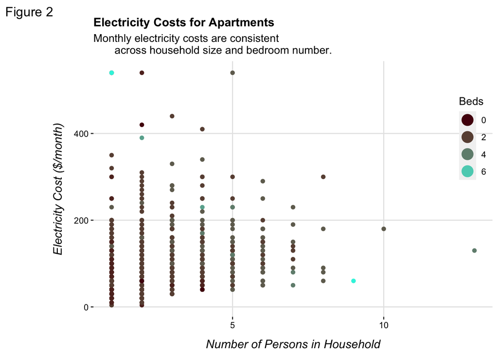

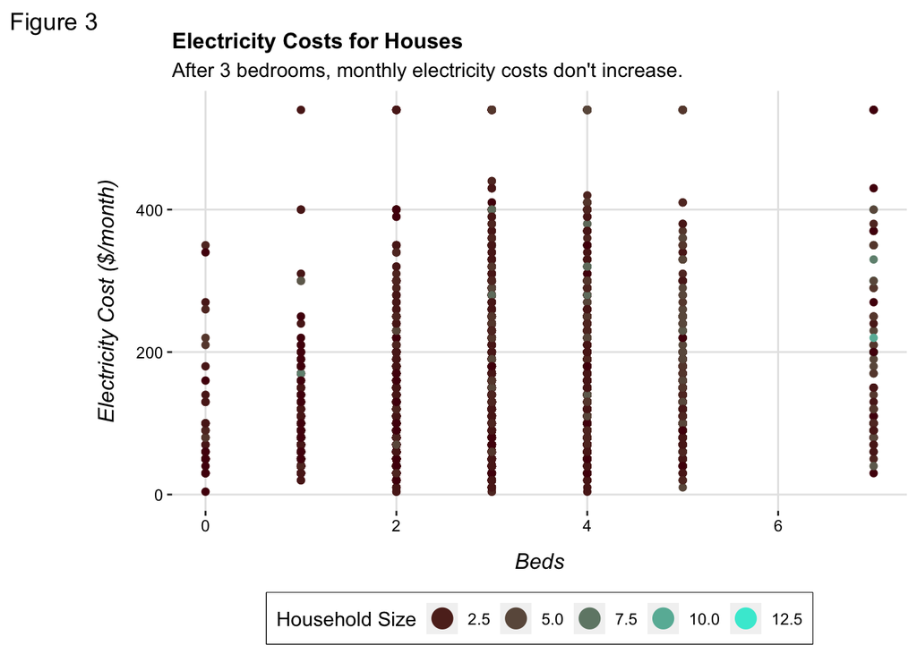

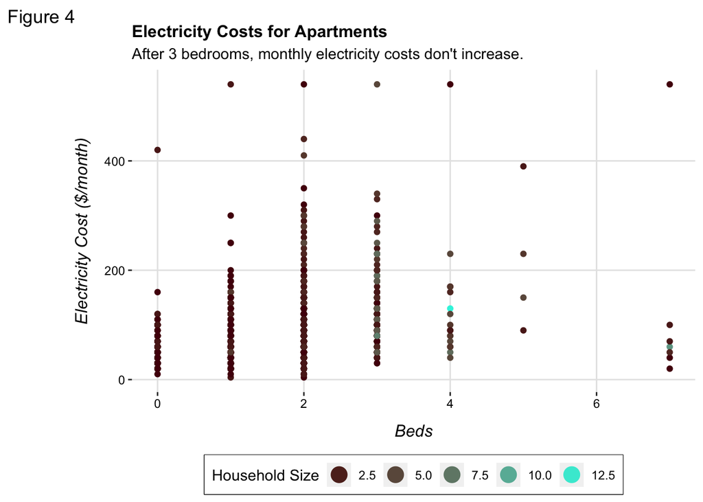

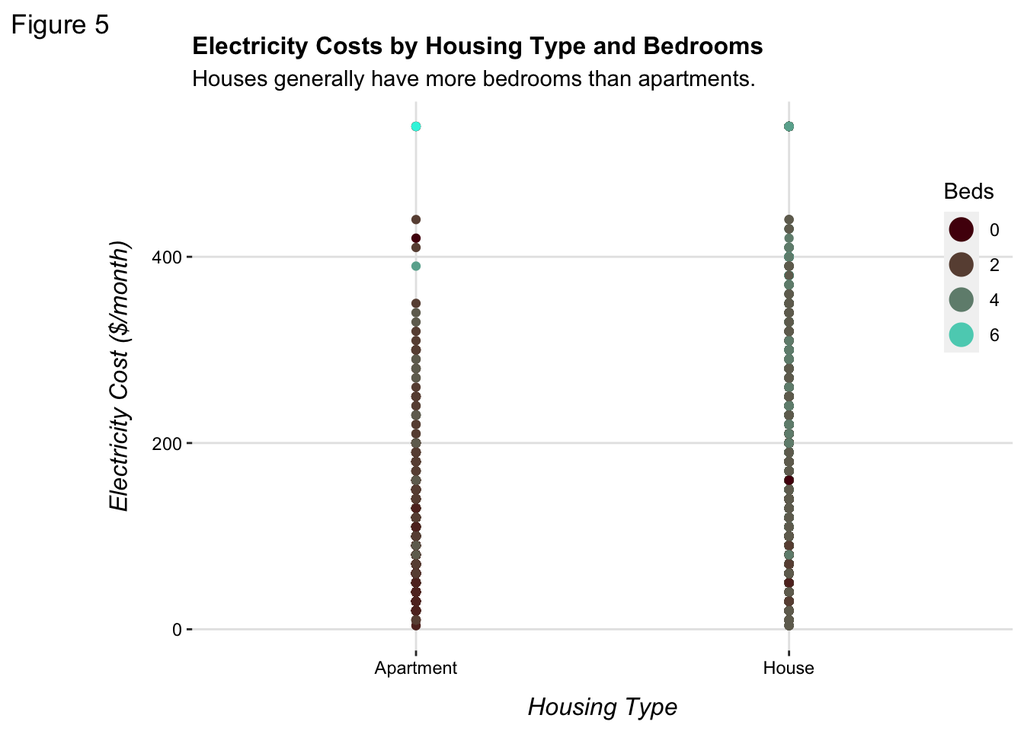

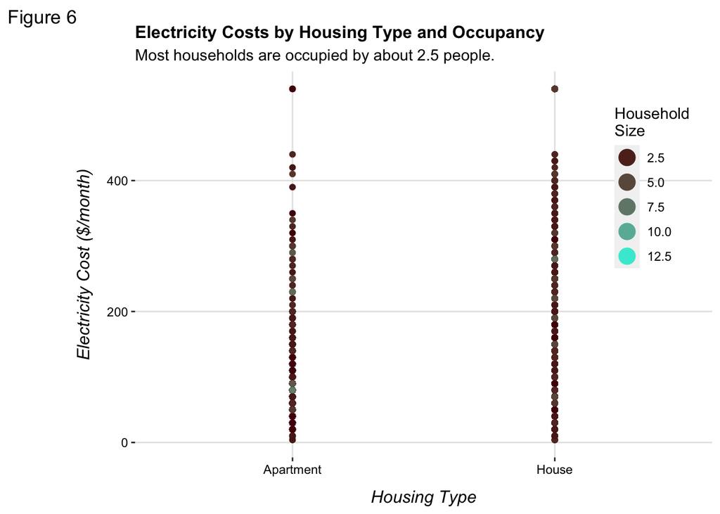

Most apartments have electricity bills that are between $0 and $350 per month (Figure 6) while most houses seem to have electricity bills that are between $0 and $425 per month (Figure 6). Apartments with a high number of bedrooms appear to be evenly distributed across the range of electricity costs (Figure 2). On the other hand, the majority of houses with 6 or more bedrooms have a monthly electricity cost over $200 (Figure 1). For houses, monthly electricity cost seems to rise as the number of bedrooms increase until three, after which the electricity cost does not appear to increase with additional bedrooms (Figure 3). Although there are more instances of large household sizes at greater bedroom numbers, the majority of households are under five persons across all bedroom sizes (Figure 3). Apartments seem to follow the same trends as houses in electricity cost and household size but it is hard to say as there are very few apartments with over three bedrooms (Figure 4). With that in mind, it does appear that monthly electricity cost does increase with each additional bedroom up to two bedrooms and larger household sizes are fairly exclusive to large bedroom apartments (Figure 4). Most households are occupied by about 2.5 people for both apartments and houses (Figure 6). Houses generally have more bedrooms than apartments (Figure 5). The initial plots show some indication of non-linearity which should be investigated further. The skewness observed in the plots should not be an issue because of the large sample size (n = 13774, Table 1).

# Methods

**Sampling**

The housing units were sampled using systematic sampling where cases were randomly selected at a regular interval. If a housing unit was selected, a file containing the housing data was added to its corresponding Public Use Microdata Area (PUMA) - a sample within a geographic area containing at least 100,000 people. To answer out two questions of interest, we will use the Student’s T-Test and a Multiple Linear Regression Model:

**Students T-Test**

The Student’s t-test, first described by William Sealy Gosset in 1908, is used to test a statistical hypothesis when the test-statistic follows a Student’s T-distribution (Student, 1908). The t-test has two assumptions:

1. Normality - the sample mean should follow a normal distribution (under the Central Limit Theorem, large samples will approximately follow a normal distribution)
2. Independence - the observations should be independent from each other.

A justification for all assumptions are included in the appendix.

**Multiple Linear Regression Model**

A multiple linear regression models the relationship between one response variable (monthly electricity cost) and multiple explanatory variables using a straight line (Galton, 1898 and Pearson, 1896). The multiple linear regression model has 5 assumptions:

1. Linearity - there is a linear relationship between the response and explanatory variables.
2. Homoskedascity - equal variances.
3. Normality - the residuals are normally distributed.
4. Multicolinearity - the independent variables are not highly correlated with each other.
5. Independence - the observations are independent of each other.

A justification for the assumptions can be found in the appendix.

# Results

**Do people living in apartments pay less for electricity than those living in houses?**

To answer the question of whether people living in apartments pay less in electricity than those living in houses, we must specify a set of models that captures the relationship between household type and monthly electricity cost while controlling for the number of bedrooms and number of occupants in the housing unit.

The following model describes the relationship between monthly electricity cost for a housing unit ($ELEP_i$), the number of occupants within the household ($NP$), the number of bedrooms in the household ($BDSP$) and whether the household is a house or an apartment ($house_i$ = 1 if house, 0 if apt). The error in the estimate is given by $\epsilon_i$.

$$ELEP_i = \beta_0 + \beta_1NP +
\beta_2BDSP + \beta_3house_i + \epsilon_i$$

Each beta coefficient ($\beta_1, \beta_2, \beta_3$) determines the strength of the effect of its corresponding variable ($NP, BDSP, house_i$). If $\beta_3$, the coefficient corresponding to the housing type variable, is equal to 0 then the housing type has no effect on electricity cost and we can conclude that people living in apartments and those living in houses pay the same in electricity when accounting for the homes occupancy and number of bedrooms. To test if $\beta_3 = 0$, we can use a Student’s T-test.

The hypotheses for our question of interest are as follows:

$H_0: \beta_3 = 0$ i.e. Houses and apartments have the same electricity costs when controlling for number of bedrooms and occupancy.

$H_A: \beta_3 > 0$ i.e. Houses have higher electricity costs than apartments when controlling for number of bedrooms and occupancy.

Alternatively, if the effect of the number of bedrooms or the number of occupants depends on the household type, we should account for these interactions. In this case our model would be more complex:

$$ELEP_i = \beta_0 + \beta_1NP +
\beta_2BDSP + \beta_3house_i + \beta_4(house_i \times NP) +
\beta_5(house_i \times BDSP) + \beta_6(BDSP \times NP) +
\epsilon_i$$

- The three-way interaction between household type, number of bedrooms, and number of occupants is a complex interaction that is hard to interpret and, therefore, it was excluded from the model.

The additional parameters describe the interactions between each variable. People living in houses may have larger household sizes than those living in apartments ($house_i \times NP$). People living in houses may also have more bedrooms than those living in apartments ($house_i \times BDSP$). Housing units with more bedrooms might have more occupants ($BDSP \times NP$). We can compare the more complex model with the simpler model to determine which one better fits our data. Ultimately, it was determined that the simpler model is a better fit to the data and a comparison of the two models can be found in the appendix.

According to our original hypotheses,

$H_0: \beta_3 = 0$ and $H_A: \beta_3 > 0$

We perform a Student’s t-test on the reduced model.

Table 3

|  | Estimate | Std. Error | T-Value | P-Value |
| --- | --- | --- | --- | --- |
| Intercept | 39.99788 | 1.8686695 | 21.40447 | 5.134693e-100 |
| Housing Type (House) | 19.47313 | 1.7932360 | 10.85921 | 2.327360e-27 |
| Number of Bedrooms | 10.36737 | 0.7213878 | 14.37143 | 1.696103e-46 |
| Household Occupancy | 12.03562 | 0.4683361 | 25.69868 | 2.664254e-142 |

Table 4

|  | 2.5% CI | 95% CI |
| --- | --- | --- |
| Intercept | 36.335033 | 43.66073 |
| Housing Type (House) | 15.958141 | 22.98812 |
| Number of Bedrooms | 8.953356 | 11.78139 |
| Household Occupancy | 11.117616 | 12.95362 |

With a p-value of less than 2.2e-16, we reject the null hypothesis that $\beta_3 = 0$ (Table 3). In other words, housing type does have an effect on monthly electricity cost. With 95% confidence, people who live in houses pay between $15.96 and $22.99 more in electricity per month, on average, than those living in apartments while controlling for the number of bedrooms and the number of occupants in the household (Table 4).

**A predictive model for monthly electricity costs in Oregon**

To determine the set of models we will consider, we will use best subset selection with the regsubsets() function in R. The regsubsets() function outputs Cp, BIC, RSS, and adjusted $R^2$, a consensus of these metrics will be found to determine how many parameters to include in the model and regsubsets() will determine which parameters will be included in the model. To validate our model, we will use cross validation by setting aside 20% of the data as a test set. A description of the missing data is included in the appendix.

We create dummy variables for all of the categorical variables: house heating fuel, tenure, year built, presence of persons under 18 in household, and presence of persons over 60 in the household. We use regsubsets() to select the best variables for our model. To determine which of these models would be the best, we can evaluate the plots.

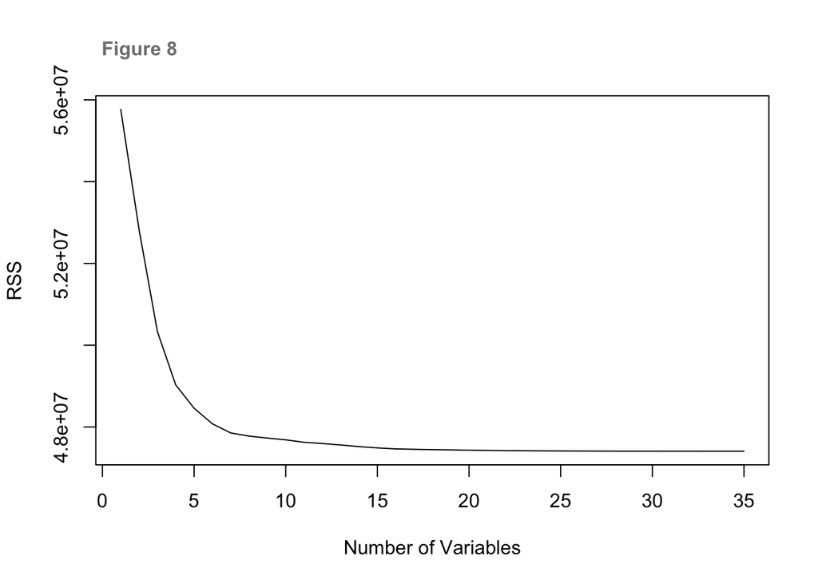

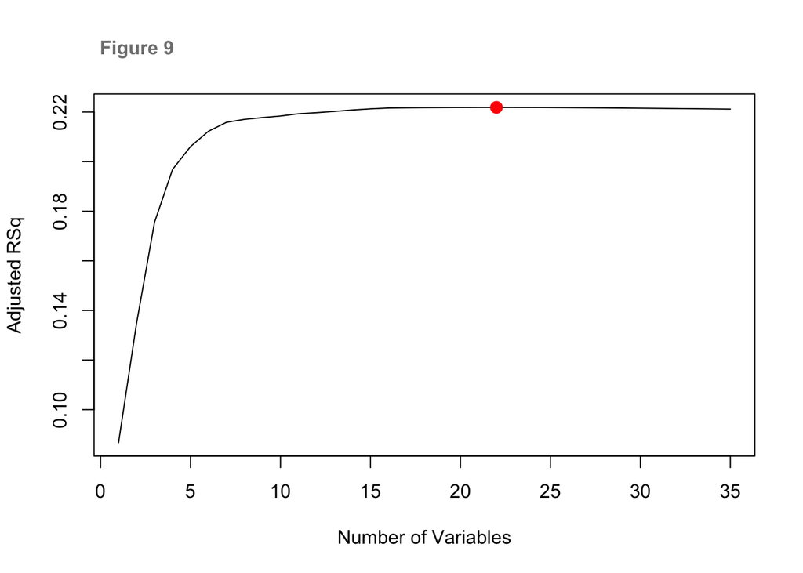

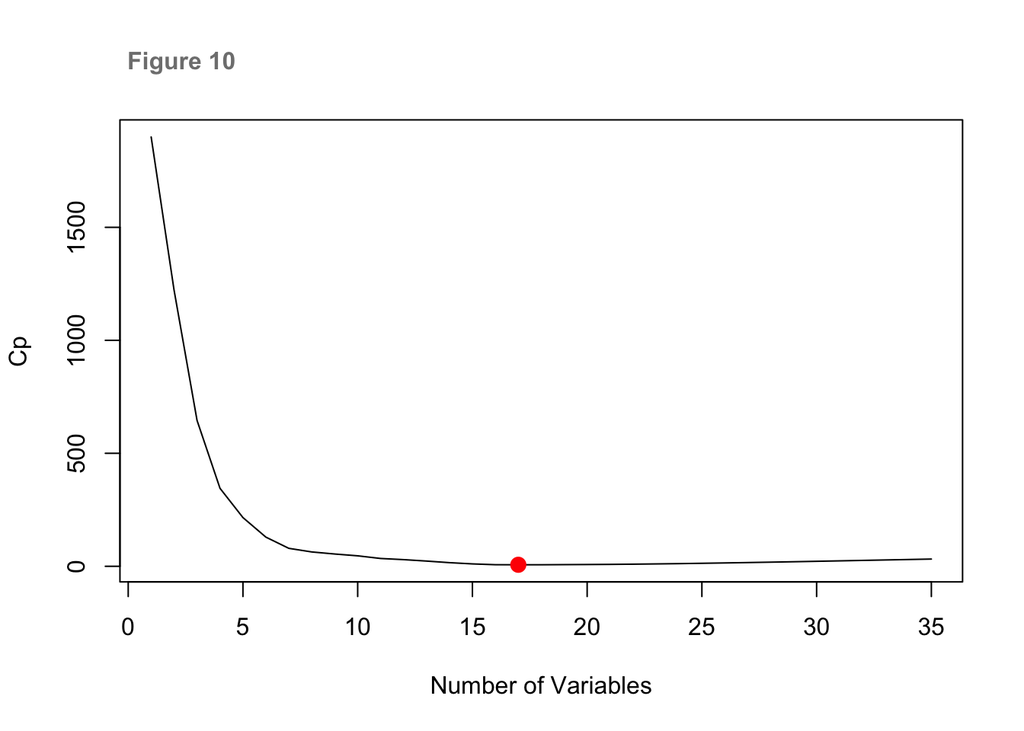

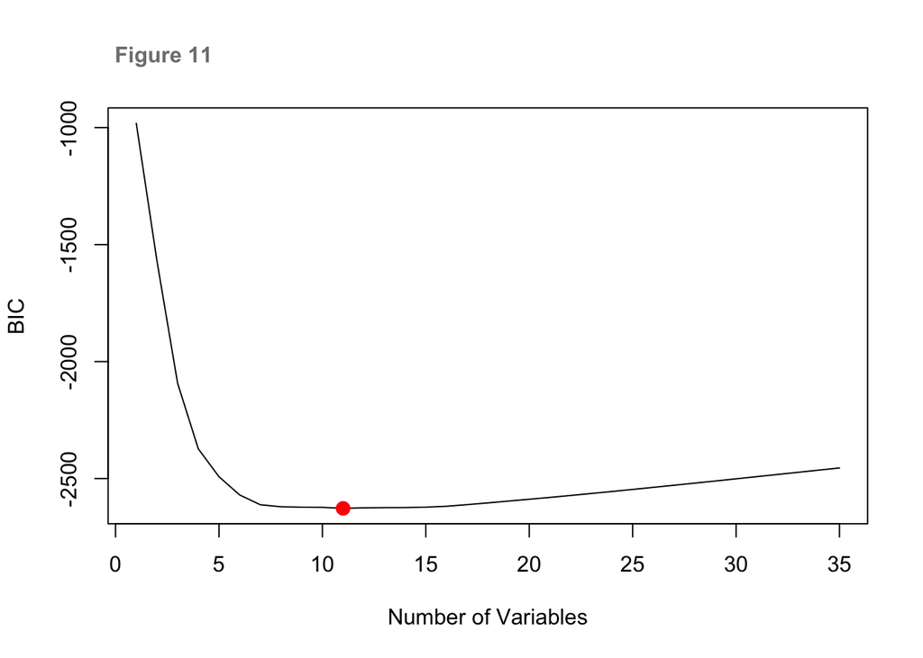

1. NP - Number of people in household
2. BDSP - Number of bedrooms
3. FULP - Fuel cost (yearly)
4. GASP - Gas cost (monthly)
5. RMSP - Number of rooms
6. HAhouse - Housing type
7. HFL1 - House heating fuel (Utility gas)
8. HFL3 - House heating fuel (Electricity)
9. HFL6 - House heating fuel (Wood)
10. HFL8 - House heating fuel (Other fuel)
11. TEN1 - Tenure (Owned with mortgage or loan)
12. TEN4 - Tenure (Occupied without payment of rent)
13. YBL02 - Year built (1940 to 1949)
14. YBL03 - Year built (1950 to 1959)
15. YBL04 - Year built (1960 to 1969)
16. YBL05 - Year built (1970 to 1979)
17. YBL06 - Year built (1980 to 1989)

The selected model is described by the following equation:

$$ELEP_i = \beta_0 + \beta_1NP +
\beta_2BDSP + \beta_3FULP + \beta_4GASP + \beta_5RMSP +...$$
$$..+ \beta_6HA + \beta_7HFL1 + \beta_8HFL3 +
\beta_9HFL6 + \beta_{10}HFL8 + \beta_{11}TEN1 +..$$

$$..+ \beta_{12}TEN4 + \beta_{13}YBL02 +
\beta_{14}YBL03 + \beta_{15}YBL04 + \beta_{16}YBL05 + \beta_{17}YBL06 +
\epsilon_i$$
To validate the model, we fit the model using the training data, make predictions with the resulting model on our test data, and calculate the error rate.

| R2 | RMSE | MAE | NRMSE |
| --- | --- | --- | --- |
| 0.2055873 | 66.22193 | 45.74311 | 0.5843149 |

The mean cost of electricity for the test data is 113.33. The root mean squared error, AKA the average distance between the model predicted values and the observed values, is 66.22. The normalized RMSE, which divides the RMSE by the average cost of electricity for the test data, is 0.584. MAE is the Mean Absolute Error which is the average of the absolute values of the errors. The MAE of 45.74 means that on average, the model predicts a value that is $45.74 less than or greater than the true value. Some of this error may be due to ELEP being “top-coded” meaning that it’s truncated at $999. To assess this, let’s determine how much of the predictions are above the true value:

| Residuals.Above.Zero | Residuals.Below.Zero |
| --- | --- |
| 1718 | 1036 |

There are 1718 residuals above 0 and 1036 residuals below 0 meaning that about 62% of the models predictions were greater than the “true” value, and 37.5% of the model’s predictions were less than the “true” value. This could be congruent with the claim that the model’s predictions are accurate and the sampling method is the cause of the error. This is a limitation in our model and more precise data collection methods could result in more accurate predictions. Additionally, it appears that the model’s predictions were less accurate for houses than for apartments. This makes sense because there are many more variables to take into account for houses like lot size and the value of the property which were two variables that were discarded for this analysis.

# Discussion and Conclusion

The purpose of this report was to:

**Investigate whether people living in apartments pay less in electricity than those living in houses and, if so, by how much?**

We found that people living in apartments do pay less for electricity. With 95% confidence, people who live in houses pay between $15.96 and $22.99 more in electricity per month, on average, than those living in apartments (PValue = 2.2e-16, T-Test).

**Create a predictive model for household electricity costs in Oregon.**

The predictive model:

$$ELEP_i = \beta_0 + \beta_1NP +
\beta_2BDSP + \beta_3FULP + \beta_4GASP + \beta_5RMSP +...$$

$$..+ \beta_6HA + \beta_7HFL1 +
\beta_8HFL3 + \beta_9HFL6 + \beta_{10}HFL8 + \beta_{11}TEN1
+..$$

$$..+ \beta_{12}TEN4 + \beta_{13}YBL02 +
\beta_{14}YBL03 + \beta_{15}YBL04 + \beta_{16}YBL05 + \beta_{17}YBL06 +
\epsilon_i$$
was selected. This model had an MAE value of 45.74 which means that on average, the model predicts a value that is $45.74 less than or greater than the true value. Since the mean cost of electricity for the test data is $113.33, an error of $45.74 is not very good. Some of this error may be due to electricity cost being truncated at $999.

**Limitations**

The PUMS sample is a subset of the full ACS sample so it is prone to additional sampling error. Estimates that arise from PUMS data will have a greater standard error than estimates from the full ACS dataset. There are some limitations to this analysis. Due to truncated variables, our model’s predictions could be more accurate than our data which could introduce bias into the error metrics. There may have been error introduced by nonresponse bias, missing value imputation, by interviewers or by data entry and processing.

# Appendix

**Load Data**

```r
# load data
data_OR <- read.csv('OR_acs_house_occ.csv', stringsAsFactors = TRUE)

# create a copy of data_OR
df <- data_OR
```

**Data Wrangling**

```r
# DATA WRANGLING

# replace bs with NAs
df$ACR[df$ACR == 'b'] <- NA
df$BDSP[df$BDSP == 'bb'] <- NA
df$ELEP[df$ELEP == 'bbb'] <- NA
df$FULP[df$FULP == 'bbbb'] <- NA
df$GASP[df$GASP == 'bbb'] <- NA
df$HFL[df$HFL == 'b'] <- NA
df$RMSP[df$RMSP == 'bb'] <- NA
df$TEN[df$TEN == 'b'] <- NA
df$VALP[df$VALP == 'bbbbbbb'] <- NA
df$YBL[df$YBL == 'bb'] <- NA
df$R18[df$R18 == 'b'] <- NA
df$R60[df$R60 == 'b'] <- NA

# remove vacant lots (NP=00) and homes with no bedrooms (BDSP = NA)
df <- subset(df, df$NP != 00)
df <- subset(df, is.na(df$BDSP) == FALSE)

# Only keep house and apartments (BLP) name this variable HA
df$HA <- "other" #initialize everything to 'other'
df$HA[which(grepl("house", df$BLD))] <- "house"
df$HA[which(grepl("apartment", df$BLD, ignore.case=TRUE))] <- "apt"
df$HA <- factor(df$HA)

# we only want rows with houses or apartments
df <- subset(df, df$HA != 'other')
df <- droplevels(df)

# drop BLD and serialno, we don't need them
df <- select(df, -BLD, -SERIALNO)
```

**Data Exploration**

```r
# Exploration
# number of rows (sample size)
n <- nrow(df)

# number of columns (variables)
p <- ncol(df)

# summary statistics for electricity
elec_sum <- summary(df$ELEP)

# summary statistics for electricity costs of apartments
apt_summ <- subset(df, df$HA == 'apt')
apt_elec_sum <- summary(apt_summ$ELEP)

# summary statistics for electricity costs of houses
house_summ <- subset(df, df$HA == 'house')
house_elec_sum <- summary(house_summ$ELEP)

# put data summary into dataframe
data_sum <- data.frame(c(n, p), row.names = c("Sample Size",
                                              "Number of Variables"))

# rename the column
colnames(data_sum) <- c("Total")

# create a beautiful table (data summary)
formattable(data_sum, caption = "Table 1")
```

Table 1

|  | Total |
| --- | --- |
| Sample Size | 13774 |
| Number of Variables | 15 |

```r
# put electricity summary into data frame
summary_table <- data.frame(cbind(elec_sum, apt_elec_sum, house_elec_sum),
                            row.names = c("Min", "First Quartile",
                                          "Median", "Mean",
                                          "Third Quartile", "Max"))

# rename the columns
colnames(summary_table) <- c("Electricity Cost (monthly)",
                             "Electricity Cost (Apartments, monthly)",
                             "Electricity Cost (Houses, monthly)")

# swap rows and columns
summary_table = data.frame(t(summary_table))

# create a beautiful table (electricity cost summary)
formattable(summary_table, list(
  `Min` = color_bar("lightgrey"),
  `First.Quartile` = color_bar("lightgreen"),
  `Median` = color_bar("lightblue"),
  `Mean` = color_bar("lightpink"),
  `Third.Quartile` = color_bar("orange"),
  `Max` = color_bar("lightgrey")
  ), caption = "Table 2")
```

Table 2

|  | Min | First.Quartile | Median | Mean | Third.Quartile | Max |
| --- | --- | --- | --- | --- | --- | --- |
| Electricity Cost (monthly) | 4 | 70 | 100 | 114.08538 | 140 | 540 |
| Electricity Cost (Apartments, monthly) | 4 | 50 | 70 | 81.16719 | 100 | 540 |
| Electricity Cost (Houses, monthly) | 4 | 70 | 100 | 121.60014 | 150 | 540 |

```r
# Figure 1
# NP vs. ELEP for houses
ggplot(data = house_summ, aes(x = NP, y = ELEP, color=BDSP)) +
  geom_point() +
  labs(x="Number of Persons in Household",
       y = "Electricity Cost ($/month)",
       title = "Electricity Costs for Houses",
       subtitle = "Most houses with six or more bedrooms have monthly
       electricity bills over $200.",
       tag = "Figure 1",
       color = "Beds") +
  scale_color_gradient(high = "#2FF3E0", low = "#52050c") +
  guides(color = guide_legend(override.aes = list(size=5))) +
  theme(axis.title.x = element_text(margin = margin(t=10), size = 12,
                                    face = 'italic'),
        axis.title.y = element_text(margin = margin(r=10), size = 12,
                                    face = 'italic'),
        axis.text = element_text(color = "black"),
        plot.title = element_text(face = "bold", size = 12),
        legend.position = c(0.95, 0.7),
        panel.background = element_rect(fill = "transparent"),
        panel.grid.major = element_line(color = "gray90"),
        legend.background = element_rect(fill = "transparent"))


# Figure 2
# NP vs. ELEP for apartments
ggplot(data = apt_summ, aes(x = NP, y = ELEP, color=BDSP)) +
  geom_point() +
  labs(x="Number of Persons in Household",
       y = "Electricity Cost ($/month)",
       title = "Electricity Costs for Apartments",
       subtitle = "Monthly electricity costs are consistent across
       household size and bedroom number.",
       tag = "Figure 2",
       color = "Beds") +
  scale_color_gradient(high = "#2FF3E0", low = "#52050c") +
  guides(color = guide_legend(override.aes = list(size=5))) +
  theme(axis.title.x = element_text(margin = margin(t=10), size = 12,
                                    face = 'italic'),
        axis.title.y = element_text(margin = margin(r=10), size = 12,
                                    face = 'italic'),
        axis.text = element_text(color = "black"),
        plot.title = element_text(face = "bold", size = 12),
        legend.position = c(0.95, 0.7),
        panel.background = element_rect(fill = "transparent"),
        panel.grid.major = element_line(color = "gray90"),
        legend.background = element_rect(fill = "transparent"))


# Figure 3
# BDSP vs. ELEP for houses
ggplot(data = house_summ, aes(x = BDSP, y = ELEP, color=NP)) +
  geom_point() +
  labs(x="Beds",
       y = "Electricity Cost ($/month)",
       title = "Electricity Costs for Houses",
       subtitle = "After 3 bedrooms, monthly electricity costs don't increase.",
       tag = "Figure 3",
       color = "Household Size") +
  scale_color_gradient(high = "#2FF3E0", low = "#52050c") +
  guides(color = guide_legend(override.aes = list(size=5))) +
  theme(axis.title.x = element_text(margin = margin(t=10), size = 12,
                                    face = 'italic'),
        axis.title.y = element_text(margin = margin(r=10), size = 12,
                                    face = 'italic'),
        axis.text = element_text(color = "black"),
        plot.title = element_text(face = "bold", size = 12),
        legend.position = "bottom",
        panel.background = element_rect(fill = "transparent"),
        panel.grid.major = element_line(color = "gray90"),
        legend.box.background = element_rect(fill = "grey70"))

# Figure 4
# BDSP vs. ELEP for apartments
ggplot(data = apt_summ, aes(x = BDSP, y = ELEP, color=NP)) +
  geom_point() +
  labs(x="Beds",
       y = "Electricity Cost ($/month)",
       title = "Electricity Costs for Apartments",
       subtitle = "After 3 bedrooms, monthly electricity costs don't increase.",
       tag = "Figure 4",
       color = "Household Size") +
  scale_color_gradient(high = "#2FF3E0", low = "#52050c") +
  guides(color = guide_legend(override.aes = list(size=5))) +
  theme(axis.title.x = element_text(margin = margin(t=10), size = 12,
                                    face = 'italic'),
        axis.title.y = element_text(margin = margin(r=10), size = 12,
                                    face = 'italic'),
        axis.text = element_text(color = "black"),
        plot.title = element_text(face = "bold", size = 12),
        legend.position = "bottom",
        panel.background = element_rect(fill = "transparent"),
        panel.grid.major = element_line(color = "gray90"),
        legend.box.background = element_rect(fill = "grey70"))

# Figure 5
# ELEP vs. HA
# qplot(ELEP, HA, data = df, color = BDSP)
ggplot(data = df, aes(x = HA, y = ELEP, color=BDSP)) +
  geom_point() +
  labs(x="Housing Type",
       y = "Electricity Cost ($/month)",
       title = "Electricity Costs by Housing Type and Bedrooms",
       subtitle = "Houses generally have more bedrooms than apartments.",
       tag = "Figure 5",
       color = "Beds") +
  scale_color_gradient(high = "#2FF3E0", low = "#52050c") +
  guides(color = guide_legend(override.aes = list(size=5))) +
  scale_x_discrete(labels = c("Apartment", "House")) +
  theme(axis.title.x = element_text(margin = margin(t=10), size = 12,
                                    face = 'italic'),
        axis.title.y = element_text(margin = margin(r=10), size = 12,
                                    face = 'italic'),
        axis.text = element_text(color = "black"),
        plot.title = element_text(face = "bold", size = 12),
        legend.position = c(0.95, 0.7),
        panel.background = element_rect(fill = "transparent"),
        panel.grid.major = element_line(color = "gray90"),
        legend.background = element_rect(fill = "transparent"))

# Figure 6
# ELEP vs. HA
# qplot(ELEP, HA, data = df, color = NP)
ggplot(data = df, aes(x = HA, y = ELEP, color=NP)) +
  geom_point() +
  labs(x="Housing Type",
       y = "Electricity Cost ($/month)",
       title = "Electricity Costs by Housing Type and Occupancy",
       subtitle = "Most households are occupied by about 2.5 people.",
       tag = "Figure 6",
       color = "Household \nSize") +
  scale_color_gradient(high = "#2FF3E0", low = "#52050c") +
  guides(color = guide_legend(override.aes = list(size=5))) +
  scale_x_discrete(labels = c("Apartment", "House")) +
  theme(axis.title.x = element_text(margin = margin(t=10), size = 12,
                                    face = 'italic'),
        axis.title.y = element_text(margin = margin(r=10), size = 12,
                                    face = 'italic'),
        axis.text = element_text(color = "black"),
        plot.title = element_text(face = "bold", size = 12),
        legend.position = c(0.90, 0.7),
        panel.background = element_rect(fill = "transparent"),
        panel.grid.major = element_line(color = "gray90"),
        legend.background = element_rect(fill = "transparent"))
```

**T-test assumptions**

*Normality*

Since the sample size is large (n = 13774, Table 1), we can assume normality under the Central Limit Theorem.

*Independence*

Since the housing units were sampled randomly using systematic sampling, we can assume that the two samples are independent of one another [See page 5 of the PUMS Accuracy Assessment for an in-depth description of the sample design](https://www2.census.gov/programs-surveys/acs/tech_docs/pums/accuracy/2011_2015AccuracyPUMS.pdf).

**Multiple Linear Regression Model Assumptions**

```r
## Check MLR assumptions
red_elem <- lm(ELEP ~ HA + BDSP + NP, data = df)

#### Residual Diagnostics ####
elep_diag <- augment(red_elem, df)
```

*Normality*

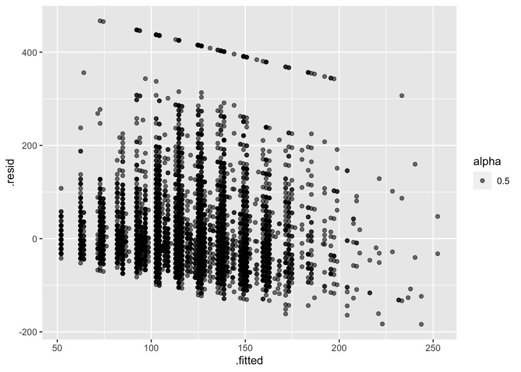

```r
qplot(.fitted, .resid, data = elep_diag, alpha=0.5)
```

*Constant Variance*

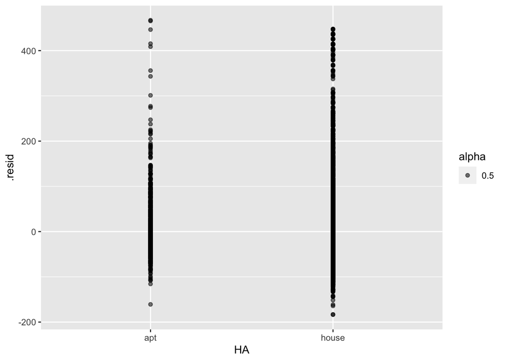

```r
qplot(HA, .resid, data = elep_diag, alpha=0.5)
```

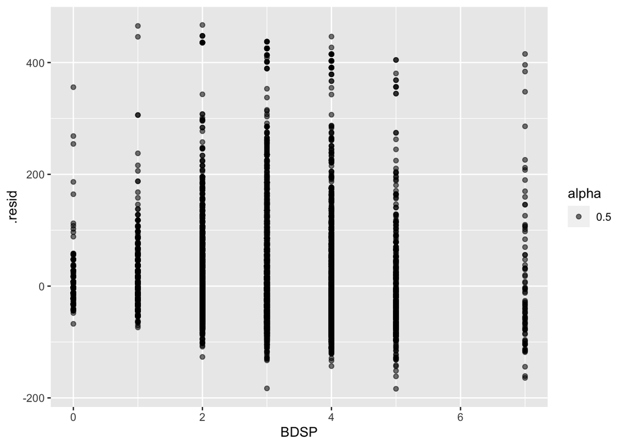

```r
qplot(BDSP, .resid, data = elep_diag, alpha = 0.5)
```

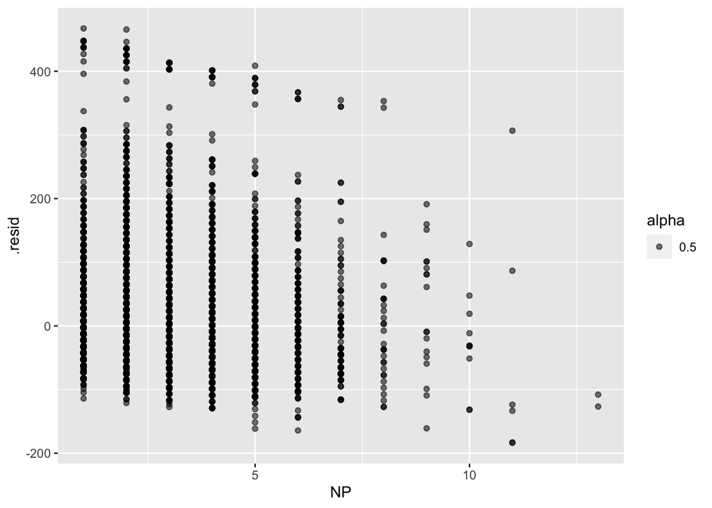

```r
qplot(NP, .resid, data = elep_diag, alpha=0.5)
```

The .resid vs BDSP plot and the .resid vs HA plot appear to meet the constant variance assumption. There may be non-constant variance from left to right in the .resid vs. NP plot, however this may be explained by less observations at high NP values.

*Independence* Since each household was sampled randomly, it means that we can extend our inference to all households in Oregon that have at least one person, pay for their electricity, and are not group accommodation.

*Multicolinearity* We check using Variance Inflation Factor (VIF) values.

```r
# calculate the VIF for each predictor in the model
vif(red_elem)
```

```
##       HA     BDSP       NP
## 1.381300 1.545368 1.149212
```

Since all VIF values are below 5, we can assume that there is no multicolinearity.

**Compare full and reduced models**

```r
#### Fit Models ####

elep_lm <- lm(ELEP ~ HA * BDSP * NP, data = df)
red_elem <- lm(ELEP ~ HA + BDSP + NP, data = df)

summary(elep_lm)
```

```
##
## Call:
## lm(formula = ELEP ~ HA * BDSP * NP, data = df)
##
## Residuals:
##     Min      1Q  Median      3Q     Max
## -187.57  -44.31  -14.54   25.23  465.47
##
## Coefficients:
##                 Estimate Std. Error t value Pr(>|t|)
## (Intercept)       24.192      5.496   4.402 1.08e-05 ***
## HAhouse           32.600      7.151   4.559 5.20e-06 ***
## BDSP              20.848      2.791   7.468 8.60e-14 ***
## NP                18.715      2.939   6.367 1.98e-10 ***
## HAhouse:BDSP      -9.970      3.139  -3.176 0.001495 **
## HAhouse:NP        -5.013      3.369  -1.488 0.136722
## BDSP:NP           -3.972      1.134  -3.503 0.000461 ***
## HAhouse:BDSP:NP    3.591      1.226   2.929 0.003402 **
## ---
## Signif. codes:  0 '***' 0.001 '**' 0.01 '*' 0.05 '.' 0.1 ' ' 1
##
## Residual standard error: 69.62 on 13766 degrees of freedom
## Multiple R-squared:  0.1249, Adjusted R-squared:  0.1245
## F-statistic: 280.8 on 7 and 13766 DF,  p-value: < 2.2e-16
```

```r
summary(red_elem)
```

```
##
## Call:
## lm(formula = ELEP ~ HA + BDSP + NP, data = df)
##
## Residuals:
##     Min      1Q  Median      3Q     Max
## -183.70  -42.98  -14.64   25.13  467.23
##
## Coefficients:
##             Estimate Std. Error t value Pr(>|t|)
## (Intercept)  39.9979     1.8687   21.40   <2e-16 ***
## HAhouse      19.4731     1.7932   10.86   <2e-16 ***
## BDSP         10.3674     0.7214   14.37   <2e-16 ***
## NP           12.0356     0.4683   25.70   <2e-16 ***
## ---
## Signif. codes:  0 '***' 0.001 '**' 0.01 '*' 0.05 '.' 0.1 ' ' 1
##
## Residual standard error: 69.66 on 13770 degrees of freedom
## Multiple R-squared:  0.1238, Adjusted R-squared:  0.1236
## F-statistic: 648.2 on 3 and 13770 DF,  p-value: < 2.2e-16
```

```r
# Remove non-significant interactions one by one
# With a p-value of 0.136722, there is no evidence that the interaction
# coefficient for HAhouse:NP is not 0, there is no evidence that
# HA and NP interact

# Since 3 way interactions are difficult to interpret,
# we won't include them in a model like this.

elep_lm_fixed <- lm(ELEP ~ HA + BDSP + NP + BDSP*NP + HA*BDSP,
                    data = df)
summary(elep_lm_fixed)
```

```
##
## Call:
## lm(formula = ELEP ~ HA + BDSP + NP + BDSP * NP + HA * BDSP, data = df)
##
## Residuals:
##     Min      1Q  Median      3Q     Max
## -183.97  -43.65  -14.81   24.76  467.25
##
## Coefficients:
##              Estimate Std. Error t value Pr(>|t|)
## (Intercept)   35.0291     3.6922   9.487  < 2e-16 ***
## HAhouse       20.9916     4.2202   4.974 6.64e-07 ***
## BDSP          12.5276     1.7828   7.027 2.21e-12 ***
## NP            13.7411     1.4029   9.795  < 2e-16 ***
## BDSP:NP       -0.5373     0.4102  -1.310    0.190
## HAhouse:BDSP  -1.0188     1.9377  -0.526    0.599
## ---
## Signif. codes:  0 '***' 0.001 '**' 0.01 '*' 0.05 '.' 0.1 ' ' 1
##
## Residual standard error: 69.66 on 13768 degrees of freedom
## Multiple R-squared:  0.1239, Adjusted R-squared:  0.1236
## F-statistic: 389.5 on 5 and 13768 DF,  p-value: < 2.2e-16
```

```r
# With a p-value of 0.599, there is no evidence that the interaction
# coefficient for HAhouse:BDSP is not 0,
# there is no evidence that HA and BDSP interact

elep_lm_fixed_2 <- lm(ELEP ~ HA + BDSP + NP + BDSP*NP, data = df)
summary(elep_lm_fixed_2)
```

```
##
## Call:
## lm(formula = ELEP ~ HA + BDSP + NP + BDSP * NP, data = df)
##
## Residuals:
##     Min      1Q  Median      3Q     Max
## -184.22  -43.87  -14.81   24.57  467.57
##
## Coefficients:
##             Estimate Std. Error t value Pr(>|t|)
## (Intercept)  36.0126     3.1831  11.314   <2e-16 ***
## HAhouse      18.9898     1.8202  10.433   <2e-16 ***
## BDSP         11.8293     1.1891   9.948   <2e-16 ***
## NP           13.9684     1.3346  10.466   <2e-16 ***
## BDSP:NP      -0.6036     0.3903  -1.547    0.122
## ---
## Signif. codes:  0 '***' 0.001 '**' 0.01 '*' 0.05 '.' 0.1 ' ' 1
##
## Residual standard error: 69.65 on 13769 degrees of freedom
## Multiple R-squared:  0.1239, Adjusted R-squared:  0.1236
## F-statistic: 486.8 on 4 and 13769 DF,  p-value: < 2.2e-16
```

```r
# With a p-value of 0.122, there is no evidence that the interaction
# coefficient for BDSP:NP is not 0,
# there is no evidence that NP and BDSP interact

# We end with the simpler model:
red_elem <- lm(ELEP ~ HA + BDSP + NP, data = df)

# Since the interaction terms were deemed insignificant,
# we can proceed with the initial strategy of testing the hypothesis that
# beta_3 = 0.
```

**T-Test**

```r
#### T-TEST ####
red_elem_sum <- summary(red_elem)
red_elem_conf <- confint(red_elem)

red_elem_sum_df <- data.frame(red_elem_sum$coef,
                              row.names = c("Intercept",
                                            "Housing Type (House)",
                                            "Number of Bedrooms",
                                            "Household Occupancy"))
red_elem_conf_df <- data.frame(red_elem_conf,
                               row.names = c("Intercept",
                                             "Housing Type (House)",
                                             "Number of Bedrooms",
                                             "Household Occupancy"))

colnames(red_elem_sum_df) <- c("Estimate", "Std. Error", "T-Value", "P-Value")
colnames(red_elem_conf_df) <- c("2.5% CI", "95% CI")

formattable(red_elem_sum_df, caption = "Table 3")
```

Table 3

|  | Estimate | Std. Error | T-Value | P-Value |
| --- | --- | --- | --- | --- |
| Intercept | 39.99788 | 1.8686695 | 21.40447 | 5.134693e-100 |
| Housing Type (House) | 19.47313 | 1.7932360 | 10.85921 | 2.327360e-27 |
| Number of Bedrooms | 10.36737 | 0.7213878 | 14.37143 | 1.696103e-46 |
| Household Occupancy | 12.03562 | 0.4683361 | 25.69868 | 2.664254e-142 |

```r
formattable(red_elem_conf_df, caption = "Table 4")
```

Table 4

|  | 2.5% CI | 95% CI |
| --- | --- | --- |
| Intercept | 36.335033 | 43.66073 |
| Housing Type (House) | 15.958141 | 22.98812 |
| Number of Bedrooms | 8.953356 | 11.78139 |
| Household Occupancy | 11.117616 | 12.95362 |

**Explore Missing Data**

```r
# DEALING WITH MISSING VALUES
# describe quantitatively the distribution of missing values
# sum the missing values
NA_in_ACR <- sum(is.na(df$ACR))
NA_in_ELEP <- sum(is.na(df$ELEP))
NA_in_FULP <- sum(is.na(df$FULP))
NA_in_GASP <- sum(is.na(df$GASP))
NA_in_HFL <- sum(is.na(df$HFL))
NA_in_RMSP <- sum(is.na(df$RMSP))
NA_in_TEN <- sum(is.na(df$TEN))
NA_in_VALP <- sum(is.na(df$VALP))
NA_in_YBL <- sum(is.na(df$YBL))
NA_in_R18 <- sum(is.na(df$R18))
NA_in_R60 <- sum(is.na(df$R60))

# create a data frame with the missing values
dist_df <- data.frame(Variable =
                         c("Lot Size",
                           "Electricity Cost (monthly)",
                           "Fuel Cost",
                           "Gas Cost (monthly)",
                           "House Heating Fuel",
                           "Number of Rooms",
                           "Tenure",
                           "Property Value",
                           "Year Built",
                           "Persons Under 18 in Household",
                           "Persons Over 60 in Household"),
                       Number_Missing =
                         c(NA_in_ACR,
                           NA_in_ELEP,
                           NA_in_FULP,
                           NA_in_GASP,
                           NA_in_HFL,
                           NA_in_RMSP,
                           NA_in_TEN,
                           NA_in_VALP,
                           NA_in_YBL,
                           NA_in_R18,
                           NA_in_R60))
# create a beautiful table
formattable(dist_df, list(
  Number_Missing = color_bar("lightblue")
), caption = "Table 5")
```

Table 5

| Variable | Number_Missing |
| --- | --- |
| Lot Size | 2560 |
| Electricity Cost (monthly) | 0 |
| Fuel Cost | 0 |
| Gas Cost (monthly) | 0 |
| House Heating Fuel | 0 |
| Number of Rooms | 0 |
| Tenure | 0 |
| Property Value | 4360 |
| Year Built | 0 |
| Persons Under 18 in Household | 0 |
| Persons Over 60 in Household | 0 |

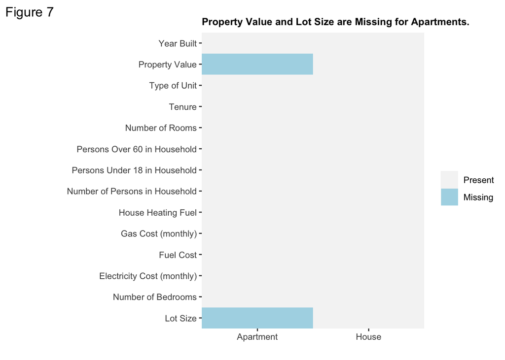

```r
# plot missing values
#gather
suppressWarnings(df_long <- gather(df, variable, value, -HA))

#plot
ggplot(df_long, aes(x=HA, y=variable, fill=is.na(value))) +
  geom_tile()  +
  scale_fill_manual(name = "",
                    values = c("grey96", "lightblue"),
                    labels = c('Present', 'Missing')) +
  scale_y_discrete(expand = c(0,0),
                   labels= c("Lot Size",
                             "Number of Bedrooms",
                             "Electricity Cost (monthly)",
                             "Fuel Cost",
                             "Gas Cost (monthly)",
                             "House Heating Fuel",
                             "Number of Persons in Household",
                             "Persons Under 18 in Household",
                             "Persons Over 60 in Household",
                             "Number of Rooms",
                             "Tenure",
                             "Type of Unit",
                             "Property Value",
                             "Year Built")) +
  scale_x_discrete(expand = c(0,0), labels = c("Apartment", "House")) +
  labs(x = "", y ="",
       title = "Property Value and Lot Size are Missing for Apartments.",
       tag = "Figure 7") +
  theme(plot.title = element_text(size=10, face="bold"))
```

**Removing Missing Values**

```r
# remove all NA values
df <- select(df, -ACR, -VALP)
```

**Create Dummy Variables**

```r
# Create dummy variables for all the categorical variables

# create dummy HFL variable, numbering corresponds to data dictionary.
df$HFL1 <- ifelse(df$HFL == 'Utility gas', 1, 0)
df$HFL2 <- ifelse(df$HFL == 'Bottled, tank, or LP gas', 1, 0)
df$HFL3 <- ifelse(df$HFL == 'Electricity',1,0)
df$HFL4 <- ifelse(df$HFL == 'Fuel oil, kerosene, etc.', 1, 0)
df$HFL5 <- ifelse(df$HFL == 'Coal or coke', 1,0)
df$HFL6 <- ifelse(df$HFL == 'Wood', 1, 0)
df$HFL7 <- ifelse(df$HFL == 'Solar energy', 1, 0)
df$HFL8 <- ifelse(df$HFL == 'Other fuel', 1, 0)
df$HFL9 <- ifelse(df$HFL == 'No fuel used', 1, 0)

# create dummy TEN variable, numbering corresponds to data dictionary.
df$TEN1 <- ifelse(df$TEN == 'Owned with mortgage or loan',1,0)
df$TEN2 <- ifelse(df$TEN == 'Owned free and clear', 1, 0)
df$TEN3 <- ifelse(df$TEN == 'Rented',1,0)
df$TEN4 <- ifelse(df$TEN == 'Occupied without payment of rent',1,0)

# create dummy YBL variable, numbering corresponds to data dictionary.
df$YBL01 <- ifelse(df$YBL == '1939 or earlier', 1, 0)
df$YBL02 <- ifelse(df$YBL == '1940 to 1949', 1, 0)
df$YBL03 <- ifelse(df$YBL == '1950 to 1959', 1, 0)
df$YBL04 <- ifelse(df$YBL == '1960 to 1969', 1, 0)
df$YBL05 <- ifelse(df$YBL == '1970 to 1979', 1, 0)
df$YBL06 <- ifelse(df$YBL == '1980 to 1989', 1, 0)
df$YBL07 <- ifelse(df$YBL == '1990 to 1999', 1, 0)
df$YBL08 <- ifelse(df$YBL == '2000 to 2004', 1, 0)
df$YBL09 <- ifelse(df$YBL == '2005', 1, 0)
df$YBL10 <- ifelse(df$YBL == '2006', 1, 0)
df$YBL11 <- ifelse(df$YBL == '2007', 1, 0)
df$YBL12 <- ifelse(df$YBL == '2008', 1, 0)
df$YBL13 <- ifelse(df$YBL == '2009', 1, 0)
df$YBL14 <- ifelse(df$YBL == '2010', 1, 0)
df$YBL15 <- ifelse(df$YBL == '2011', 1, 0)
df$YBL16 <- ifelse(df$YBL == '2012', 1, 0)
df$YBL17 <- ifelse(df$YBL == '2013', 1, 0)
df$YBL18 <- ifelse(df$YBL == '2014', 1, 0)
df$YBL19 <- ifelse(df$YBL == '2015', 1, 0)

# create dummy R18 variable,
# if 1 or more corresponds to 1, none corresponds to 0
df$R18 <- ifelse(df$R18 == '1 or more', 1, 0)

# create dummy R60 variable,
# if 1 or more corresponds to 1, none corresponds to 0
df$R60 <- ifelse(df$R60 == '1 or more', 1, 0)

# remove all non-dummys
df <- select(df, -HFL, -TEN, -YBL, -R18, -R60)
```

**Variable Selection**

```r
# Set 20% of the data aside for a validation set
n <- nrow(df)
set.seed(2)
valid <- sample(n, size = floor(0.2*n))
test <- df[valid, ]
train <- df[-valid, ]

# use regsubsets() to find the best model
regfit.housing <- regsubsets(ELEP ~., data = train, nvmax = 50, really.big = TRUE)
```

```
## Reordering variables and trying again:
```

```r
regfit.housing.summary <- summary(regfit.housing)
regfit.housing.summary
```

```
## Subset selection object
## Call: regsubsets.formula(ELEP ~ ., data = train, nvmax = 50, really.big = TRUE)
## 39 Variables  (and intercept)
##         Forced in Forced out
## NP          FALSE      FALSE
## BDSP        FALSE      FALSE
## FULP        FALSE      FALSE
## GASP        FALSE      FALSE
## RMSP        FALSE      FALSE
## HAhouse     FALSE      FALSE
## HFL1        FALSE      FALSE
## HFL2        FALSE      FALSE
## HFL3        FALSE      FALSE
## HFL4        FALSE      FALSE
## HFL5        FALSE      FALSE
```

[output cut: 174 more lines]

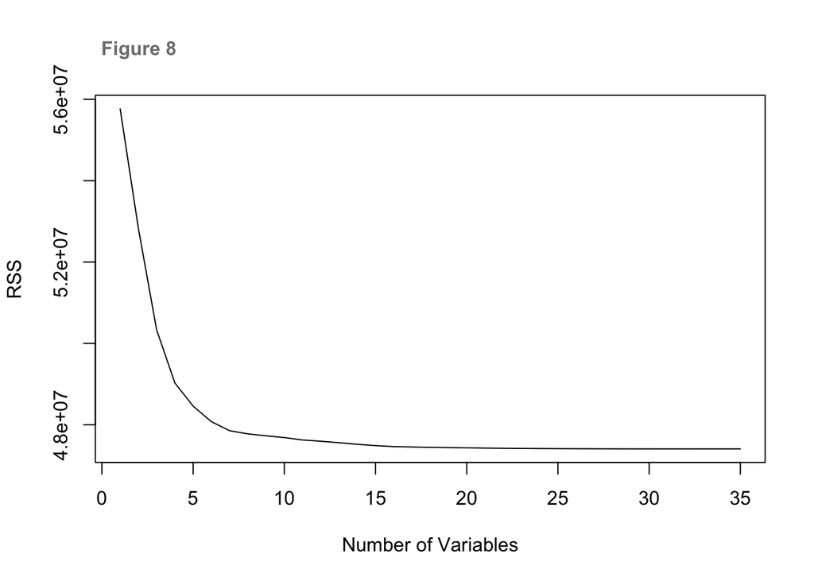

```r
# RSS plot
plot(regfit.housing.summary$rss, xlab="Number of Variables", ylab="RSS",
     type="l")
title(main = "Figure 8", cex.main = 1, adj = 0.01, col.main = "grey50")
```

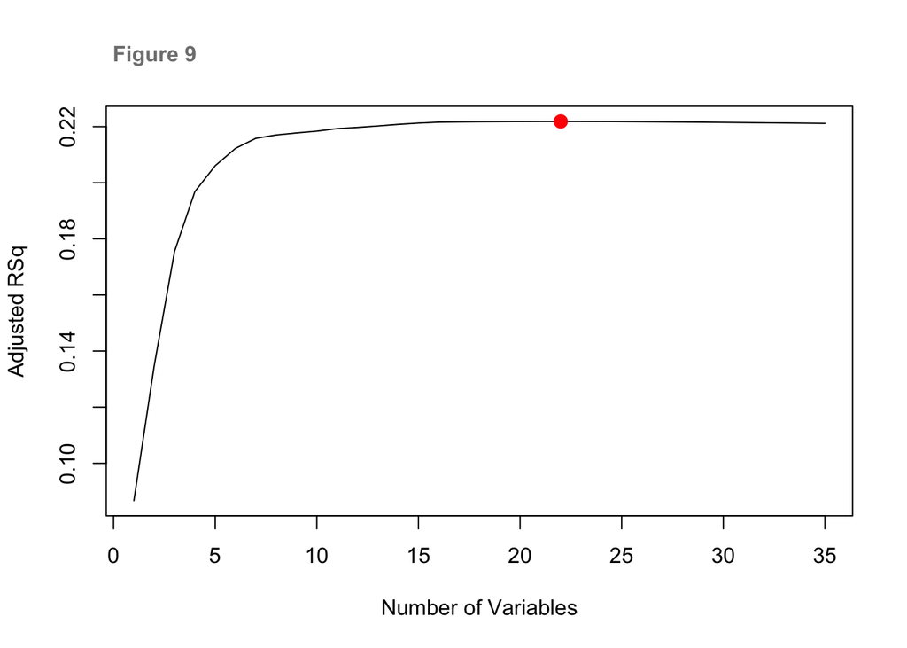

```r
# Adjusted R^2 plot
plot(regfit.housing.summary$adjr2, xlab="Number of Variables",
     ylab="Adjusted RSq", type="l")
point_rsq <- which.max(regfit.housing.summary$adjr2)
points(point_rsq, regfit.housing.summary$adjr2[point_rsq], col="red",
       cex=2, pch=20)
title(main = "Figure 9", cex.main = 1, adj = 0.01, col.main = "grey50")
```

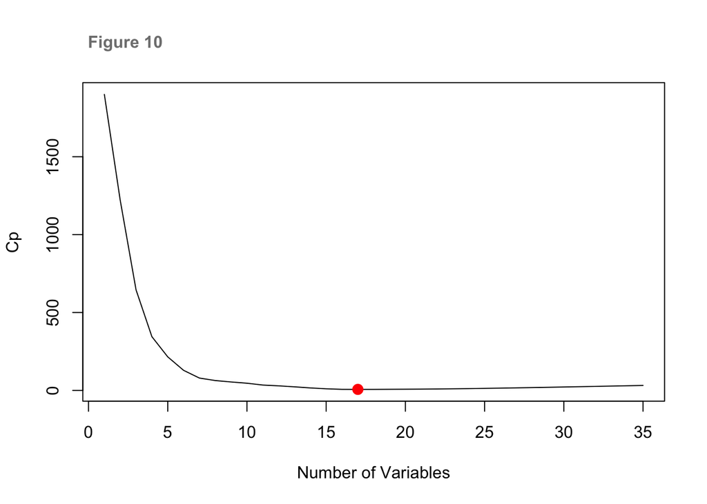

```r
# Cp plot
point_cp <- which.min(regfit.housing.summary$cp)
plot(regfit.housing.summary$cp, xlab="Number of Variables", ylab="Cp", type="l")
points(point_cp, regfit.housing.summary$cp[point_cp], col="red", cex=2, pch=20)
title(main = "Figure 10", cex.main = 1, adj = 0.01, col.main = "grey50")
```

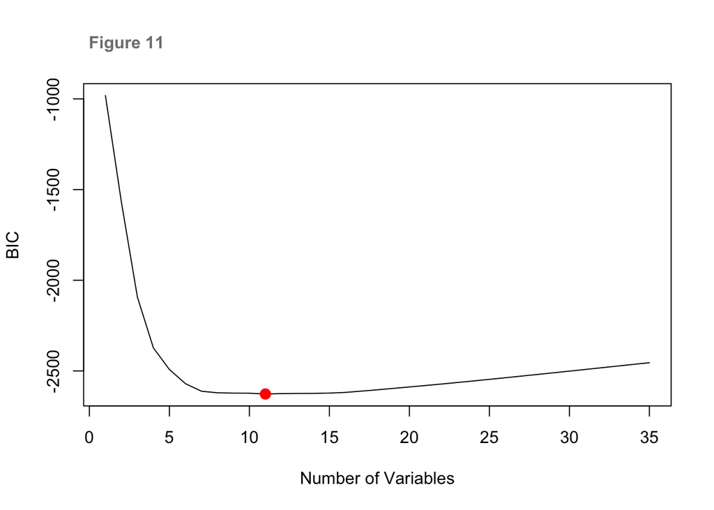

```r
# BIC plot
point_bic <- which.min(regfit.housing.summary$bic)
plot(regfit.housing.summary$bic, xlab="Number of Variables", ylab="BIC",
     type="l")
points(point_bic, regfit.housing.summary$bic[point_bic], col="red", cex=2,
       pch=20)
title(main = "Figure 11", cex.main = 1, adj = 0.01, col.main = "grey50")
```

**Validate Model**

```r
# required packages:metrics, dplyr

# R^2 formula

RSQUARE = function(y_actual,y_predict){
  cor(y_actual,y_predict)^2
  }

# Model predicted by best subset
best_sub_mod <- lm(ELEP ~ NP +
                     BDSP +
                     FULP +
                     GASP +
                     RMSP +
                     HA +
                     HFL1 +
                     HFL3 +
                     HFL6 +
                     HFL8 +
                     TEN1 +
                     TEN4 +
                     YBL02 +
                     YBL03 +
                     YBL04 +
                     YBL05 +
                     YBL06,
                   data = train)

# Prediction
prediction <- best_sub_mod %>% predict(test)
pred_error <- data.frame(R2 = RSQUARE(test$ELEP, prediction),
                         RMSE = rmse(test$ELEP, prediction),
                         MAE = mae(test$ELEP, prediction),
                         NRMSE = rmse(test$ELEP, prediction)/mean(test$ELEP))
# Error
formattable(pred_error)
```

| R2 | RMSE | MAE | NRMSE |
| --- | --- | --- | --- |
| 0.2055873 | 66.22193 | 45.74311 | 0.5843149 |

```r
# mean of the cost of electricity for the test dataset
# mean(test$ELEP)
```

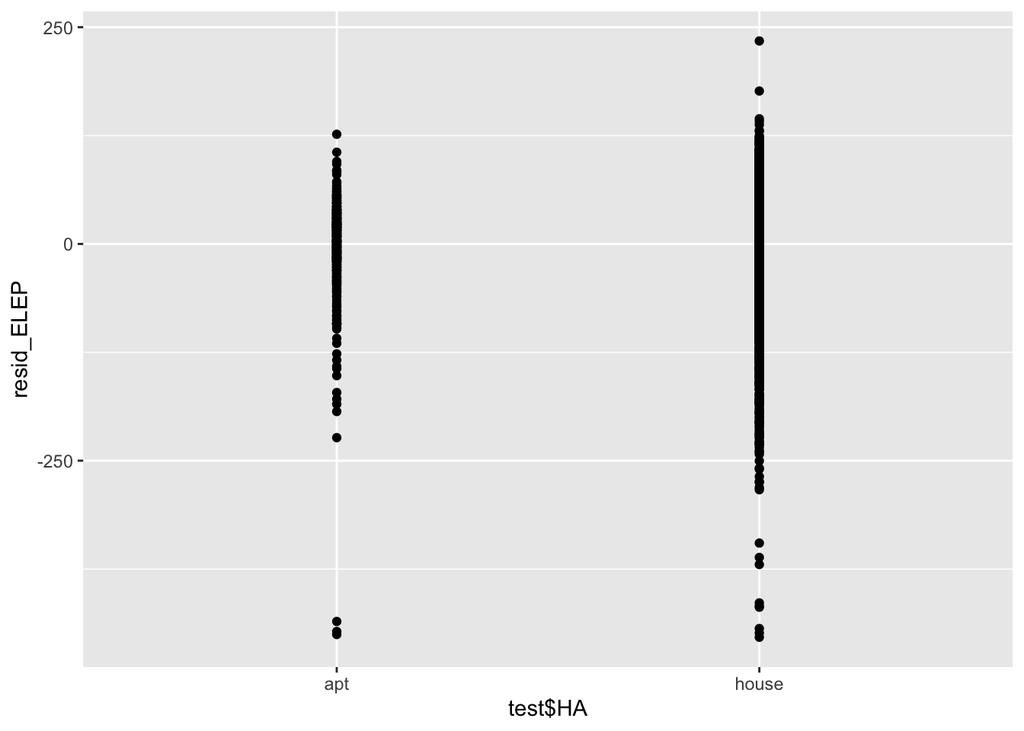

```r
# calculate the residuals
resid_ELEP <- rep(NA, 2754)

for(i in 1:2754) {
  resid_ELEP[i] <- prediction[i] - test$ELEP[i]
}

# plot the residuals against HA
qplot(x = test$HA, y = resid_ELEP)
```

```r
# find how many residuals are above and below 0
formattable(
  data.frame(`Residuals Above Zero` = length(resid_ELEP[resid_ELEP > 0]),
             `Residuals Below Zero` = length(resid_ELEP[resid_ELEP < 0])))
```

| Residuals.Above.Zero | Residuals.Below.Zero |
| --- | --- |
| 1718 | 1036 |

**Description of Variables**

- SERIALNO - a unique record identifier for each housing unit.
- NP - the number of people living in the house hold (from 0-20).
- TYPE - the type of unit
  - housing unit
  - Institutional group quarters
  - Non-institutional group quarters
- ACR - lot size
  - b - not a one-family house or mobile home
  - 1 - less than one acre
  - 2 - one to less than ten acres
  - 3 - ten or more acres
- BDSP - number of bedrooms
  - bb for NA
  - 0-99
- BLD - units in structure
  - bb - NA
  - 01 - Mobile home or trailer
  - 02 - one-family house detached
  - 03 - one-family house attached
  - 04 - 2 apartments
  - 05 - 3-4 apartments
  - 06 - 5-9 apartments
  - 07 - 10-19 apartments
  - 08 - 20-49 apartments
  - 09 - 50 or more apartments
  - Boat, RV, van, etc.
- ELEP - monthly electricity cost
  - bbb - NA
  - Included in rent or condo fee
  - 002 - No charge or electricity not used
  - 003..999 - $3 to $999 (rounded and top-coded)
- FULP Fuel cost - yearly cost for fuels other than gas and electricity
  - bbbb - NA
  - 0001 - Included in rent or in condo fee
  - 0002 - No charge or these fuels not used
  - 0003..9999 $3 to $9999 (Rounded and top-coded)
- GASP Gas - monthly cost
  - bbb - NA
  - 001 - Included in rent or in condo fee
  - 002 - Included in electricity payment
  - 003 - No charge or gas not used
  - 004..999 - $4 to $999 (Rounded and top-coded)
- HFL house heating fuel
  - b - NA
  - 1 - Utility gas
  - 2 - Bottled, tank, or LP gas
  - 3 - Electricity
  - 4 - Fuel oil, kerosene, etc.
  - 5 - Coal or coke
  - 6 - Wood
  - 7 - Solar energy
  - 8 - Other fuel
  - 9 - No fuel used
- RMSP Number of Rooms
  - bb - NA
  - 00…99 - 0 to 99 Rooms (Top-coded)
- TEN Tenure
  - b - NA
  - 1 - Owned with mortgage or loan (include home equity loans)
  - 2 - Owned free and clear
  - 3 - Rented
  - 4 - Occupied without payment of rent
- VALP Property value
  - bbbbbbb - NA
  - 0000001..9999999 - $1 to $9999999 (Rounded and top-coded)
- YBL - When structure first built
  - bb - NA
  - 01 - 1939 or earlier
  - 02 - 1940 to 1949
  - 03 - 1950 to 1959
  - 04 - 1960 to 1969
  - 05 - 1970 to 1979
  - 06 - 1980 to 1989
  - 07 - 1990 to 1999
  - 08 - 2000 to 2004
  - 09 - 2005
  - 10 - 2006
  - 11 - 2007
  - 12 - 2008
  - 13 - 2009
  - 14 - 2010
  - 15 - 2011
  - 16 - 2012
  - 17 - 2013
  - 18 - 2014
  - 19 - 2015
- R18 Presence of persons under 18 years in household (unweighted)
  - b - NA
  - 0 - No person under 18 in household
  - 1 - 1 or more persons under 18 in household
- R60 Presence of persons 60 years and over in household (unweighted)
  - b - NA
  - 0 - No person 60 and over
  - 1 - 1 person 60 and over
  - 2 - 2 or more persons 60 and over

# Works Cited

1. “Student” William Sealy Gosset (1908). “The probable error of a mean” (PDF). Biometrika. 6 (1): 1–25. doi:10.1093/biomet/6.1.1. hdl:10338.dmlcz/143545. JSTOR 2331554
2. Levene, Howard (1960). “Robust tests for equality of variances”. In Ingram Olkin; Harold Hotelling; et al. (eds.). Contributions to Probability and Statistics: Essays in Honor of Harold Hotelling. Stanford University Press. pp. 278–292.
3. Pearson, K. (1896) VII. Mathematical Contributions to the Theory of Evolution.-III. Regression, Heredity, and Panmixia. Philosophical Transactions of the Royal Society A, 187, 253-318. https://doi.org/10.1098/rsta.1896.0007
4. Galton, Francis. 1898. A diagram of heredity. Nature, 57:293.